# Homework 1: When Do Estimates Miss?

Ha Ram Cho

POLS 602, Fall 2026

*AI use: I have previously worked in Stata, and this is my first assignment in R. I used Claude as a tutor to work through the statistical concepts and R syntax for this assignment. I ran all of the code and wrote the answers with its feedback.*

```r
# Fix the random number generator so results are reproducible
set.seed(602)
```

# Problem 1: Why does the sample variance divide by n − 1?

The population is $N(0, 2)$, so the true variance is $\sigma^2 = 4$ and the true standard deviation is $\sigma = 2$.

## (a)

```r
# Function that takes a numeric vector and returns three estimates:
#   sigma2_n : sum of squared deviations divided by n
#   s2       : sum of squared deviations divided by n - 1 (sample variance)
#   s        : square root of s2 (sample standard deviation)
var_estimators <- function(x) {
  n  <- length(x)                  # number of observations
  ss <- sum((x - mean(x))^2)       # sum of squared deviations from the sample mean
  data.frame(
    sigma2_n = ss / n,             # divide-by-n version (not built into R)
    s2       = ss / (n - 1),       # divide-by-(n - 1) version, same as var(x)
    s        = sqrt(ss / (n - 1))  # same as sd(x)
  )
}

# Check the function on a simulated sample of 10 observations from N(0, 2)
x <- rnorm(10, mean = 0, sd = 2)
var_estimators(x)
```

```
##   sigma2_n       s2        s
## 1 1.748624 1.942916 1.393885
```

```r
# Compare with R's built-in functions (both should be TRUE)
all.equal(var_estimators(x)$s2, var(x))
```

```
## [1] TRUE
```

```r
all.equal(var_estimators(x)$s,  sd(x))
```

```
## [1] TRUE
```

The function’s `s2` and `s` match R’s `var()` and `sd()`, so the function is computing the estimators correctly.

## (b)

```r
# Draw 1,000 samples of size 5 and apply the function to each.
# simplify = FALSE keeps the 1,000 one-row data frames as a list.
sims_list <- replicate(1000,
                       var_estimators(rnorm(5, mean = 0, sd = 2)),
                       simplify = FALSE)

# Stack the 1,000 one-row data frames into one data frame (one row per sample)
sims5 <- do.call(rbind, sims_list)
head(sims5)
```

```
##   sigma2_n       s2        s
## 1 1.572158 1.965198 1.401855
## 2 5.201020 6.501275 2.549760
## 3 3.210456 4.013070 2.003265
## 4 7.051821 8.814776 2.968969
## 5 3.573517 4.466897 2.113503
## 6 1.691891 2.114864 1.454257
```

```r
dim(sims5)
```

```
## [1] 1000    3
```

```r
# Mean of each estimator across the 1,000 samples
colMeans(sims5)
```

```
## sigma2_n       s2        s
## 3.174576 3.968220 1.875548
```

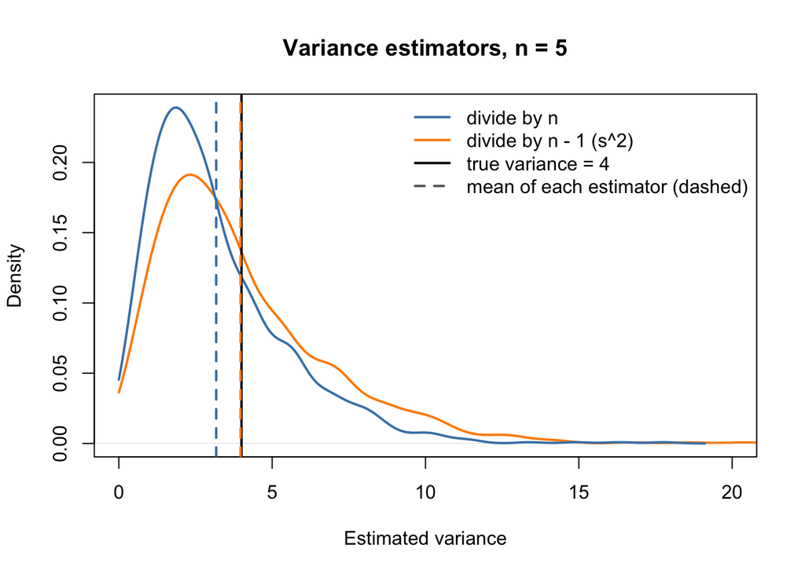

```r
# Plot the sampling distributions of the two variance estimators
d_n  <- density(sims5$sigma2_n, from = 0)
d_s2 <- density(sims5$s2, from = 0)

plot(d_s2, col = "darkorange", lwd = 2, xlim = c(0, 20),
     ylim = c(0, max(d_n$y, d_s2$y)),
     main = "Variance estimators, n = 5",
     xlab = "Estimated variance")
lines(d_n, col = "steelblue", lwd = 2)

# True variance (solid) and the mean of each estimator (dashed)
abline(v = 4, lwd = 2)
abline(v = mean(sims5$sigma2_n), col = "steelblue", lty = 2, lwd = 2)
abline(v = mean(sims5$s2), col = "darkorange", lty = 2, lwd = 2)

legend("topright",
       c("divide by n", "divide by n - 1 (s^2)", "true variance = 4", "mean of each estimator (dashed)"),
       col = c("steelblue", "darkorange", "black", "gray40"),
       lty = c(1, 1, 1, 2), lwd = 2, bty = "n")
```

Across 1,000 samples of size 5, the mean of the divide-by-*n* estimator is 3.17, while the mean of $s^2$ is 3.97 (true variance = 4). The divide-by-*n* estimator is biased downward by about 0.83, because deviations measured from the sample mean are systematically smaller than deviations from the true mean: the sample mean is the value that minimizes the sum of squared deviations. Dividing by $n - 1$ corrects for this, so $s^2$ is approximately unbiased.

## (c)

```r
sizes <- c(3, 5, 10, 30, 100)   # sample sizes to compare

# For each sample size, repeat the simulation in (b) 1,000 times
# and stack the results, with a column recording the sample size
sims_all <- do.call(rbind, lapply(sizes, function(n) {
  sims <- do.call(rbind, replicate(1000,
                                   var_estimators(rnorm(n, mean = 0, sd = 2)),
                                   simplify = FALSE))
  sims$n <- n
  sims
}))
dim(sims_all)   # 5 sample sizes x 1,000 samples = 5,000 rows
```

```
## [1] 5000    4
```

```r
# Estimated bias = mean of the 1,000 estimates - true variance (4)
bias_table <- data.frame(
  n             = sizes,
  bias_sigma2_n = sapply(sizes, function(k) mean(sims_all$sigma2_n[sims_all$n == k]) - 4),
  bias_s2       = sapply(sizes, function(k) mean(sims_all$s2[sims_all$n == k]) - 4)
)
round(bias_table, 3)
```

```
##     n bias_sigma2_n bias_s2
## 1   3        -1.208   0.187
## 2   5        -0.862  -0.077
## 3  10        -0.323   0.085
## 4  30        -0.132   0.001
## 5 100        -0.065  -0.025
```

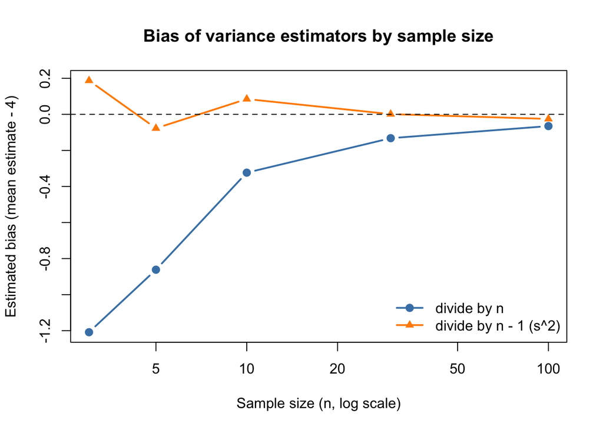

```r
# Plot bias against sample size (log scale on the x-axis)
plot(bias_table$n, bias_table$bias_sigma2_n, type = "b", pch = 19,
     col = "steelblue", lwd = 2, log = "x",
     ylim = range(c(bias_table$bias_sigma2_n, bias_table$bias_s2, 0)),
     xlab = "Sample size (n, log scale)",
     ylab = "Estimated bias (mean estimate - 4)",
     main = "Bias of variance estimators by sample size")
lines(bias_table$n, bias_table$bias_s2, type = "b", pch = 17,
      col = "darkorange", lwd = 2)
abline(h = 0, lty = 2)
legend("bottomright", c("divide by n", "divide by n - 1 (s^2)"),
       col = c("steelblue", "darkorange"), pch = c(19, 17), lwd = 2, bty = "n")
```

The divide-by-*n* estimator is biased downward at every sample size, but the bias shrinks as *n* grows: from about -1.21 at *n* = 3 to about -0.06 at *n* = 100. This matches the theoretical bias of $-\sigma^2/n = -4/n$ ($-1.33$ at *n* = 3 and $-0.04$ at *n* = 100), so the estimator is asymptotically unbiased. In contrast, the bias of $s^2$ stays close to zero at all sample sizes.

## (d)

```r
# Estimated bias of s = mean of the 1,000 values of s - true SD (2)
bias_s_table <- data.frame(
  n      = sizes,
  mean_s = sapply(sizes, function(k) mean(sims_all$s[sims_all$n == k])),
  bias_s = sapply(sizes, function(k) mean(sims_all$s[sims_all$n == k]) - 2)
)
round(bias_s_table, 3)
```

```
##     n mean_s bias_s
## 1   3  1.804 -0.196
## 2   5  1.858 -0.142
## 3  10  1.964 -0.036
## 4  30  1.984 -0.016
## 5 100  1.989 -0.011
```

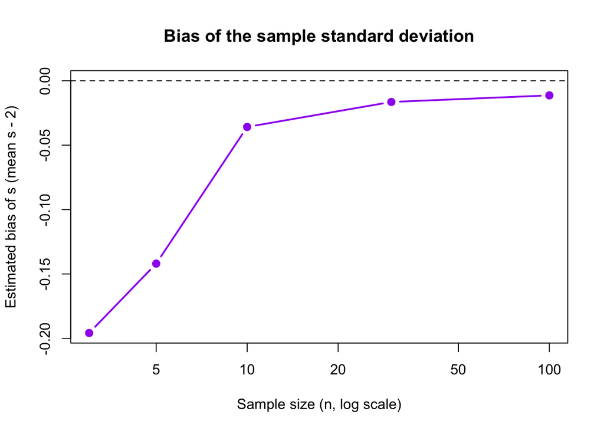

```r
# Plot the bias of s against sample size
plot(bias_s_table$n, bias_s_table$bias_s, type = "b", pch = 19,
     col = "purple", lwd = 2, log = "x",
     ylim = range(c(bias_s_table$bias_s, 0)),
     xlab = "Sample size (n, log scale)",
     ylab = "Estimated bias of s (mean s - 2)",
     main = "Bias of the sample standard deviation")
abline(h = 0, lty = 2)
```

No. $s$ is biased downward for $\sigma = 2$ at every sample size: the estimated bias is -0.2 at *n* = 3, -0.14 at *n* = 5, -0.04 at *n* = 10, -0.02 at *n* = 30, and -0.01 at *n* = 100. Although $s^2$ is unbiased for $\sigma^2$, taking the square root does not preserve unbiasedness: the square root pulls large values of $s^2$ down more than it pulls small values, so the average of $s$ falls below 2. Because $s^2$ varies more in small samples, the bias is largest when *n* is small and shrinks toward zero as *n* grows.

## (e)

```r
# Variability of each variance estimator at n = 5 (using the 1,000 estimates from (b))
sd(sims5$sigma2_n)
```

```
## [1] 2.254325
```

```r
sd(sims5$s2)
```

```
## [1] 2.817906
```

```r
sd(sims5$sigma2_n) / sd(sims5$s2)   # ratio should be exactly 4/5
```

```
## [1] 0.8
```

At *n* = 5, the standard deviation of the divide-by-*n* estimates is 2.25, compared with 2.82 for $s^2$, so the divide-by-*n* estimator is less variable (exactly 4/5 as variable, since it is $s^2$ multiplied by 4/5). However, lower variability does not make it the better estimator, because its estimates are shrunk toward the wrong value: they cluster around 3.2 rather than the true variance of 4. An estimator that always reported 3, regardless of the data, would have zero variability but would always be wrong. A good estimator should be centered on the truth, not just precise.

# Problem 2: Omitted Variable Bias

True data-generating process: $z_i \sim N(0,1)$, $x_i = \rho z_i + \sqrt{1-\rho^2}\,u_i$, $y_i = 1 + 2x_i + 3z_i + \epsilon_i$. The estimand is $\beta_1 = 2$.

## (a)

```r
# Function that generates one dataset from the true DGP for a given n and rho
make_data <- function(n, rho) {
  z   <- rnorm(n)                        # political interest ~ N(0, 1)
  u   <- rnorm(n)                        # other causes of news use ~ N(0, 1)
  eps <- rnorm(n)                        # error ~ N(0, 1)
  x   <- rho * z + sqrt(1 - rho^2) * u   # news consumption, correlated with z
  y   <- 1 + 2 * x + 3 * z + eps         # political knowledge (true beta1 = 2)
  data.frame(y, x, z)
}

# One dataset with n = 100 and rho = 0.5
d100 <- make_data(100, rho = 0.5)

# Check: x and z should have mean ~0 and sd ~1, and cor(x, z) should be ~0.5
round(c(mean_x = mean(d100$x), sd_x = sd(d100$x),
        mean_z = mean(d100$z), sd_z = sd(d100$z)), 2)
```

```
## mean_x   sd_x mean_z   sd_z
##   0.02   1.14   0.02   0.97
```

```r
round(cor(d100), 2)
```

```
##      y   x    z
## y 1.00 0.8 0.88
## x 0.80 1.0 0.50
## z 0.88 0.5 1.00
```

The simulated variables have the expected distributions: *x* and *z* have means near 0 and standard deviations near 1, and their correlation is 0.5, close to $\rho = 0.5$.

## (b)

```r
# Fit the theorized model (omits z) and the true model (includes z)
m_short <- lm(y ~ x, data = d100)       # researcher ignores political interest
m_full  <- lm(y ~ x + z, data = d100)   # true model

coef(m_short)
```

```
## (Intercept)           x
##   0.9501463   3.1934757
```

```r
coef(m_full)
```

```
## (Intercept)           x           z
##   0.9279043   1.9118488   3.0048761
```

```r
confint(m_short)["x", ]                 # 95% CI for the x coefficient
```

```
##    2.5 %   97.5 %
## 2.715395 3.671556
```

```r
confint(m_full)["x", ]
```

```
##    2.5 %   97.5 %
## 1.713182 2.110516
```

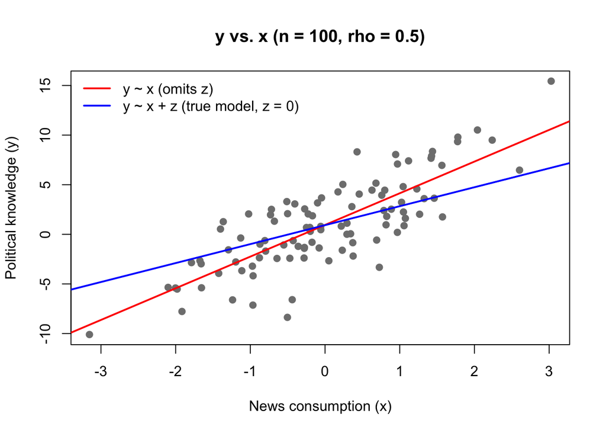

```r
# Scatterplot of y against x with the estimated slope for x from each model
plot(d100$x, d100$y, pch = 19, col = "gray50",
     xlab = "News consumption (x)", ylab = "Political knowledge (y)",
     main = "y vs. x (n = 100, rho = 0.5)")
abline(m_short, col = "red", lwd = 2)
abline(a = coef(m_full)[1], b = coef(m_full)["x"], col = "blue", lwd = 2)
legend("topleft", c("y ~ x (omits z)", "y ~ x + z (true model, z = 0)"),
       col = c("red", "blue"), lwd = 2, bty = "n")
```

## (c)

```r
# Same as (a) and (b), but with n = 1,000
d1000 <- make_data(1000, rho = 0.5)
round(cor(d1000), 2)
```

```
##      y    x    z
## y 1.00 0.76 0.89
## x 0.76 1.00 0.45
## z 0.89 0.45 1.00
```

```r
m_short_1000 <- lm(y ~ x, data = d1000)
m_full_1000  <- lm(y ~ x + z, data = d1000)

coef(m_short_1000)["x"]
```

```
##        x
## 3.359917
```

```r
coef(m_full_1000)["x"]
```

```
##        x
## 1.958638
```

```r
confint(m_short_1000)["x", ]
```

```
##    2.5 %   97.5 %
## 3.178703 3.541131
```

```r
confint(m_full_1000)["x", ]
```

```
##    2.5 %   97.5 %
## 1.889708 2.027568
```

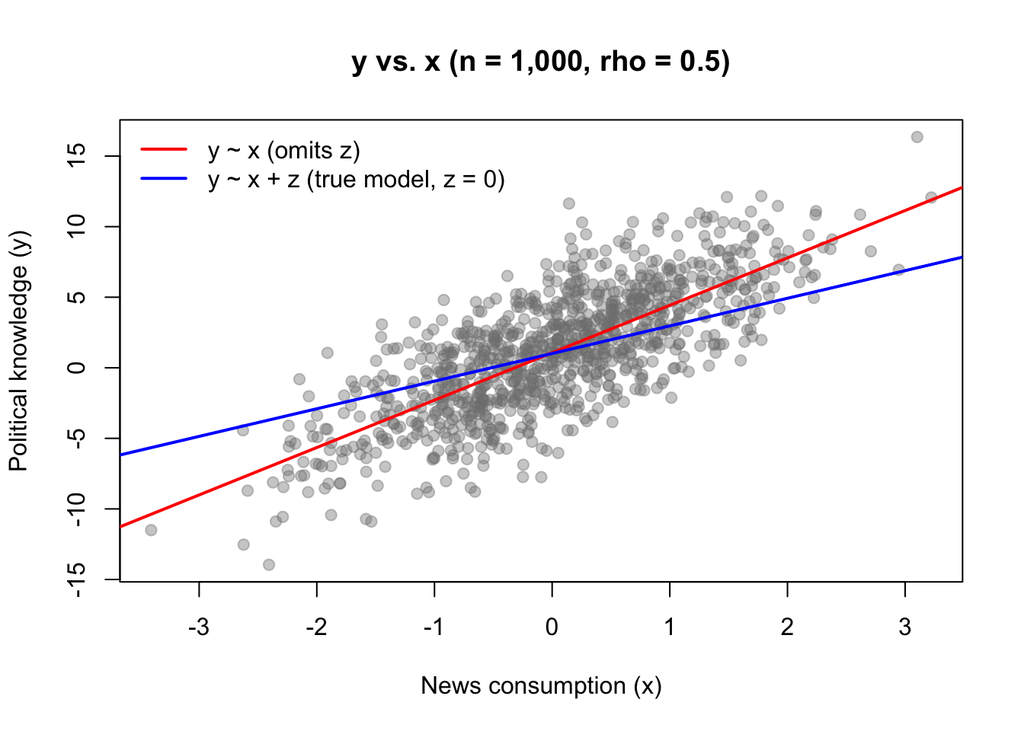

```r
plot(d1000$x, d1000$y, pch = 19, col = adjustcolor("gray50", 0.4),
     xlab = "News consumption (x)", ylab = "Political knowledge (y)",
     main = "y vs. x (n = 1,000, rho = 0.5)")
abline(m_short_1000, col = "red", lwd = 2)
abline(a = coef(m_full_1000)[1], b = coef(m_full_1000)["x"], col = "blue", lwd = 2)
legend("topleft", c("y ~ x (omits z)", "y ~ x + z (true model, z = 0)"),
       col = c("red", "blue"), lwd = 2, bty = "n")
```

With 1,000 observations, the estimate from `y ~ x` is 3.36 (95% CI: 3.18 to 3.54), essentially the same as with 100 observations. More data did not resolve the bias: the confidence interval became narrower (from a width of about 0.96 to about 0.36), but it is now more tightly concentrated around the wrong value. This is because the omitted variable bias, $\beta_2 \times \rho = 1.5$, does not depend on *n*. The model with *z* still recovers the true effect (1.96, 95% CI: 1.89 to 2.03).

## (d)

```r
# Same as (c), but with rho = 0 (z is unrelated to x)
d1000_r0 <- make_data(1000, rho = 0)
round(cor(d1000_r0), 2)                  # cor(x, z) should be ~0
```

```
##      y    x    z
## y 1.00 0.55 0.81
## x 0.55 1.00 0.04
## z 0.81 0.04 1.00
```

```r
m_short_r0 <- lm(y ~ x, data = d1000_r0)
m_full_r0  <- lm(y ~ x + z, data = d1000_r0)

coef(m_short_r0)["x"]
```

```
##        x
## 2.131654
```

```r
coef(m_full_r0)["x"]
```

```
##        x
## 2.009707
```

```r
confint(m_short_r0)["x", ]
```

```
##    2.5 %   97.5 %
## 1.933089 2.330218
```

```r
confint(m_full_r0)["x", ]
```

```
##    2.5 %   97.5 %
## 1.949060 2.070355
```

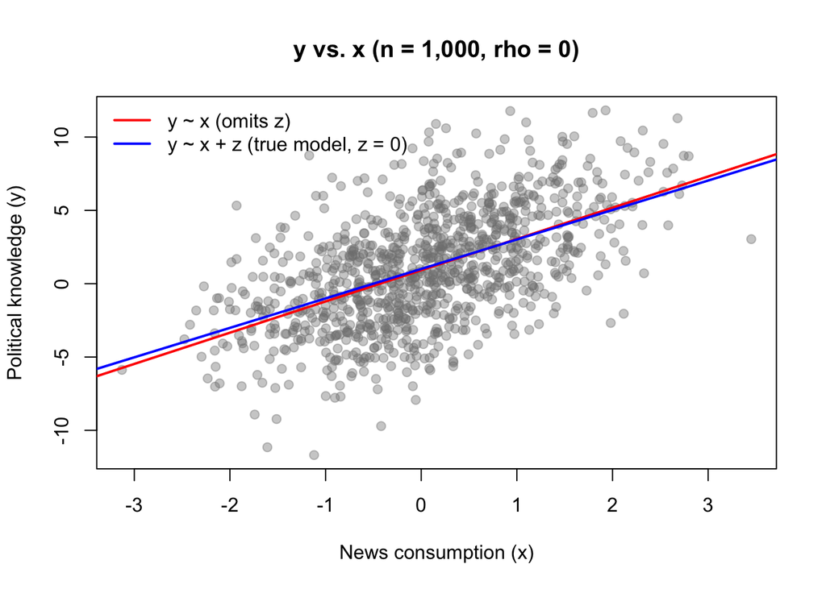

```r
plot(d1000_r0$x, d1000_r0$y, pch = 19, col = adjustcolor("gray50", 0.4),
     xlab = "News consumption (x)", ylab = "Political knowledge (y)",
     main = "y vs. x (n = 1,000, rho = 0)")
abline(m_short_r0, col = "red", lwd = 2)
abline(a = coef(m_full_r0)[1], b = coef(m_full_r0)["x"], col = "blue", lwd = 2)
legend("topleft", c("y ~ x (omits z)", "y ~ x + z (true model, z = 0)"),
       col = c("red", "blue"), lwd = 2, bty = "n")
```

When $\rho = 0$, both models estimate the effect of *x* close to the true value of 2 (`y ~ x`: 2.13; `y ~ x + z`: 2.01), so omitting *z* no longer causes bias. This is because omitted variable bias requires the omitted variable to both affect *y* and be correlated with *x*; here $\beta_2 \times \rho = 3 \times 0 = 0$. However, the confidence interval is wider without *z* (1.93 to 2.33) than with *z* (1.95 to 2.07), because without *z*, its effect on *y* is left in the error term, which increases the residual variance and the standard error of the *x* coefficient.

This implies that we should include variables that affect both *x* and *y* (confounders) to avoid bias, and that including strong predictors of *y* improves precision even when they are unrelated to *x*. Because we usually cannot observe whether an omitted variable is correlated with *x*, these choices must be guided by theory, and collecting more data does not fix the bias.